# TOLIFE D5.4 Resubmission — Germany Site Report

Pulmonary Research Institute (PRI), Grosshansdorf

Author

ISGlobal — TOLIFE WP5

Published

22 April 2026

# 1 Executive summary

Numbers are computed from the eCRF export dated **20 abril 2026**.

The dataset contains **46** German participants with at least a Visit 1 record.

**Participant disposition (this export):**

- Recruited: **46**
- Formally withdrawn: **5** (IDs 21006, 21013, 21014, 21019, 21026)
- Completed all 5 visits: **22**
- Ended early — site-confirmed: **16**
- Ended early — no documentation: **3**

Each participant’s study timeline ends at the last visit with recorded data. Participants who ended early are **not** counted as “missing data” for visits they did not reach; the denominators below reflect this.

**Data quality summary:**

There is one outstanding data quality concern at this site: three participants (21010, 21029, 21030) attended T4 with complete data but have no T5 record and no visit note explaining why. Their T5 visits were due between July 2025 and February 2026, all before this export. For the purposes of this report they are treated as having ended at T4, and are therefore **not included in the T5 denominator**; this decision requires confirmation from PRI. All other data quality indicators are satisfactory: no unjustified missing values, no duplicate records, no date anomalies, and all clinical values within plausible ranges.

# 2 Recruitment over time

Enrolment at PRI opened in mayo 2024 and remained active through octubre 2025 — a span of 18 months. The cumulative curve rises gradually without any pronounced acceleration, reflecting the regulatory challenges (MDR requirements and sponsor agreement delays) that constrained the site’s start-up and limited recruitment pace throughout the study period.

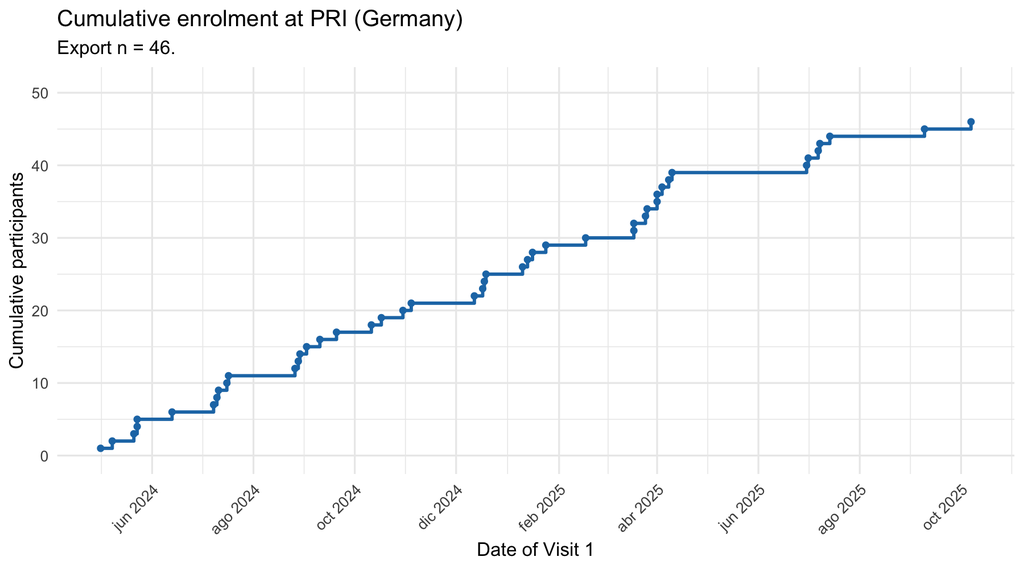

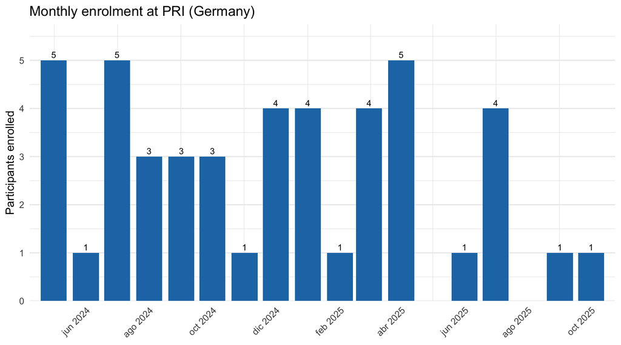

# 3 Follow-up visit completion (T1–T5)

For each participant, the **last visit with recorded data** is treated as their study endpoint. Visits they did not reach are reported as “Study ended at earlier visit” (or “Withdrawn at earlier visit” if the participant is in the withdrawal list). These participants are **not** counted as missing for those visits.

## 3.1 Visit status by timepoint

Attendance was high through the first three visits (T1: 100%, T2: 91%, T3: 87%) and drops at T4 (74%) and T5 (48%). The large “Study ended at earlier visit” segment at T5 should not be read as attrition: it largely reflects the 16 participants whose site-confirmed study end preceded T5 because they enrolled late in the recruitment period. When those are accounted for, true attrition — formal withdrawals and undocumented endings combined — is limited to 8 participants.

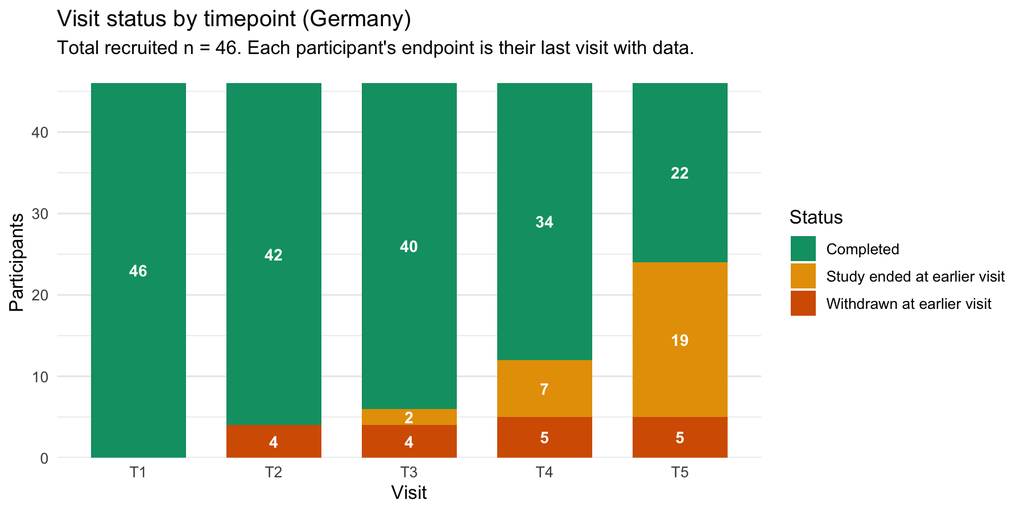

## 3.2 Study endpoints by visit

Participants by visit (n = 46). All 46 attended T1 (recruitment visit); no withdrawals are registered at T1. ‘Attended’ = reached that visit. Withdrawn participants are shown at the first visit they missed, since withdrawal is acknowledged at the subsequent scheduled visit. ‘Total ended’ includes 3 participant(s) with no documentation of ending (21010, 21029, 21030), not shown separately.

| Visit | Attended | Withdrawn | Site-confirmed end | Total ended |
| --- | --- | --- | --- | --- |
| T2 | 42 | 4 | 2 | 6 |
| T3 | 40 | 0 | 5 | 5 |
| T4 | 34 | 1 | 9 | 13 |
| T5 | 22 | NA | NA | NA |

# 4 Participant disposition & withdrawals

T1 is the recruitment visit — all 46 participants attended and no withdrawals are registered there. Participants who did not reach T5 are classified into three categories based on available documentation. Withdrawn participants are attributed to the first visit they missed (not their last attended visit), since withdrawals are acknowledged at the subsequent scheduled visit.

- **Withdrawn** — formally withdrew from the study. There are **5** such participants (IDs: 21006, 21013, 21014, 21019, 21026).
- **Site-confirmed end** — The site’s visit note explicitly states the study was completed (e.g. *“This was the last visit — study completed”*). These participants ended as planned, likely because they enrolled later in the recruitment period when fewer visits remained. There are **16** such participants.
- **No documentation of ending** — No formal withdrawal and no end statement in visit notes. These require follow-up clarification. There are **3** such participants (IDs: 21010, 21029, 21030).

## 4.1 Distribution of study endpoints

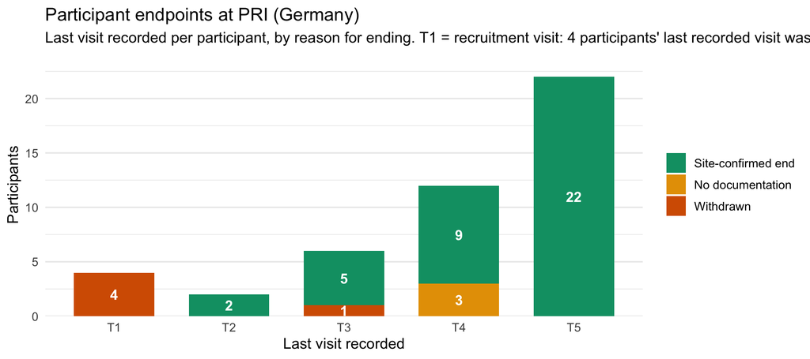

## 4.2 Early-ending participants (individual detail)

The 3 participants with no documentation of ending (21010, 21029, 21030, highlighted in red) all ended at T4 with complete T4 data and uninformative visit notes. Given that their T5 visits were due between July 2025 and February 2026 — all before this export (April 2026) — their absence from T5 is not explained by timing. PRI clarification is required to determine whether these were undocumented withdrawals, lost-to-follow-up cases, or administrative gaps.

Participants whose last recorded visit was before T5 (n = 24). 'Site-confirmed end' = visit note explicitly records last visit / study completed. 'No documentation of ending' (highlighted) = no formal withdrawal and no end statement in visit notes — these require follow-up clarification from PRI.

| Participant ID | Last visit | Last visit date | Ending documentation |
| --- | --- | --- | --- |
| 21006 | T1 | 2024-05-21 | Withdrawn |
| 21014 | T1 | 2024-08-29 | Withdrawn |
| 21019 | T1 | 2024-10-17 | Withdrawn |
| 21026 | T1 | 2025-01-10 | Withdrawn |
| 21045 | T2 | 2025-12-09 | Site-confirmed end |
| 21046 | T2 | 2026-01-15 | Site-confirmed end |
| 21013 | T3 | 2025-02-26 | Withdrawn |
| 21040 | T3 | 2025-12-29 | Site-confirmed end |
| 21041 | T3 | 2025-12-30 | Site-confirmed end |
| 21042 | T3 | 2026-01-05 | Site-confirmed end |
| 21043 | T3 | 2026-01-06 | Site-confirmed end |
| 21044 | T3 | 2025-12-11 | Site-confirmed end |
| 21010 | T4 | 2025-04-15 | No documentation of ending |
| 21029 | T4 | 2025-10-24 | No documentation of ending |
| 21030 | T4 | 2025-11-17 | No documentation of ending |
| 21031 | T4 | 2025-12-03 | Site-confirmed end |
| 21032 | T4 | 2025-12-03 | Site-confirmed end |
| 21033 | T4 | 2025-12-23 | Site-confirmed end |
| 21034 | T4 | 2025-11-27 | Site-confirmed end |
| 21035 | T4 | 2025-12-29 | Site-confirmed end |
| 21036 | T4 | 2025-12-01 | Site-confirmed end |
| 21037 | T4 | 2026-01-14 | Site-confirmed end |
| 21038 | T4 | 2026-01-06 | Site-confirmed end |
| 21039 | T4 | 2025-12-17 | Site-confirmed end |

# 5 Data quality — variable-level completion by visit

Completion is computed **only among participants who reached that visit**. Spirometry and 6-Minute Walk Test are only expected at T1, T3, T5.

Attendance-based denominators per visit: **T1 = 46, T2 = 42, T3 = 40, T4 = 34, T5 = 22**.

> **Note:** Participants 21010, 21029, and 21030 are not included in the T5 denominator. They attended T4 with complete data but have no T5 record and no visit note explaining the absence. For this report they are treated as having ended at T4 pending confirmation from PRI.

## 5.1 Heatmap

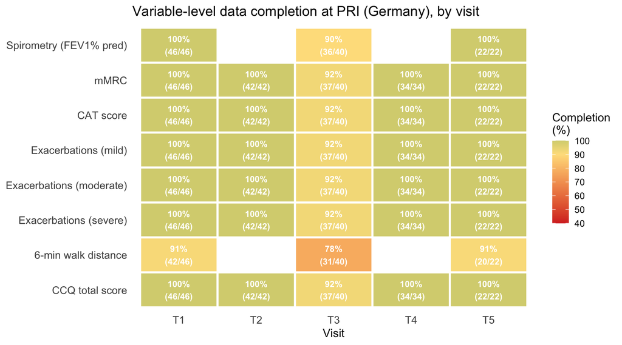

## 5.2 Attribution of missing values by reason

Critically, every missing cell in the heatmap has a documented reason in the eCRF: 34 are attributable to clinical events and 3 to site logistics. There are no unexplained missing values at this site. This indicates that PRI consistently recorded the reasons for measurement omissions, and that missing data reflects genuine clinical or operational constraints rather than data collection failures.

Attribution of the 37 missing heatmap cells (out of 1320 expected cells).

| Reason | Missing cells | ID × visit combos | % of all missing |
| --- | --- | --- | --- |
| Clinical event (exacerbation / hospital / surgery) | 34 | 13 | 91.9% |
| Site logistics | 3 | 2 | 8.1% |

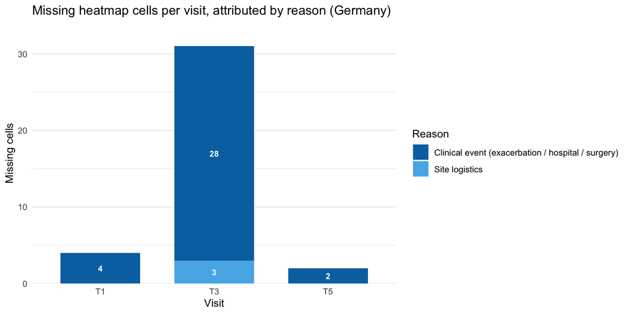

### 5.2.1 Detail — participants and visits affected, by reason

The clinical event group is dominated by 6MWT omissions due to respiratory and cardiovascular contraindications — elevated blood pressure, dyspnoea, stroke, fall-related mobility limitation, and exhaustion. Several participants contributed missing data at more than one visit (e.g. 21003 at T3 and T5; 21009 at T3 and T5), indicating persistent clinical limitations rather than isolated incidents. The 3 site logistics cells correspond to a single telephone visit (21024, T3) where physical assessments could not be performed because the patient could not attend in person, and a visit where no physicians were on site (21029, T3).

**Clinical event (exacerbation / hospital / surgery)** — 34 missing cells across 13 participant-visits.

| ID | Visit | Vars missing | Note |
| --- | --- | --- | --- |
| 21003 | T3 | 6MWD | Patient unwell; 6MWT not performed |
|  | T5 | 6MWD | Patient unwell; 6MWT not performed |
| 21007 | T1 | 6MWD | Elevated blood pressure; 6MWT not performed |
| 21009 | T3 | Spirometry, mMRC, CAT, Exac. mild, Exac. mod., Exac. sev., 6MWD, CCQ | Patient in rehabilitation |
|  | T5 | 6MWD | Knee pain; 6MWT not performed |
| 21010 | T3 | Spirometry, mMRC, CAT, Exac. mild, Exac. mod., Exac. sev., 6MWD, CCQ | Illness; visit cancelled |
| 21013 | T3 | Spirometry, mMRC, CAT, Exac. mild, Exac. mod., Exac. sev., 6MWD, CCQ | Patient ill |
| 21015 | T1 | 6MWD | Increased dyspnoea; 6MWT not performed |
| 21016 | T1 | 6MWD | Increased dyspnoea; 6MWT not performed |
| 21019 | T1 | 6MWD | Elevated resting blood pressure (PI decision); 6MWT not performed |
| 21028 | T3 | 6MWD | Patient exhausted; refused 6MWT |
| 21033 | T3 | 6MWD | Stroke (Aug 2025); 6MWT not performed |
| 21041 | T3 | 6MWD | Limited mobility due to fall; 6MWT not performed |

**Site logistics** — 3 missing cells across 2 participant-visits.

| ID | Visit | Vars missing | Note |
| --- | --- | --- | --- |
| 21024 | T3 | Spirometry, 6MWD | Telephone visit; patient unable to attend site |
| 21029 | T3 | 6MWD | No physician on site; 6MWT not performed |

# 6 Data quality findings — items for PRI review

The following items were identified during the data review and require action or confirmation from PRI before the D5.4 resubmission is finalised.

## 6.1 Participants with no documentation of study ending

Three participants ended at T4 with complete visit data but no visit note explaining why T5 was not attended. Their T5 visits were due between July 2025 and February 2026, all of which preceded this export (April 2026). PRI is asked to confirm, for each participant, whether this was an undocumented withdrawal, a loss to follow-up, or an administrative gap.

| Participant | T4 date | T5 expected | Status |
| --- | --- | --- | --- |
| 21010 | 2025-04-15 | ~2025-07-15 | No documentation |
| 21029 | 2025-10-24 | ~2026-01-23 | No documentation |
| 21030 | 2025-11-17 | ~2026-02-16 | No documentation |

# 7 Baseline characteristics

| **Characteristic** | **N = 46**<sup>1</sup> |
| --- | --- |
| Age (years) | 65.5 ± 7.7 |
| Sex |  |
| Female | 20 (43%) |
| Male | 26 (57%) |
| BMI (kg/m²) | 27.1 ± 5.0 |
| FEV1 (% predicted) | 49.4 ± 15.6 |
| FVC (% predicted) | 87.8 ± 14.6 |
| FEV1/FVC ratio | 0.4 ± 0.1 |
| GOLD grade |  |
| GOLD 2 (50-79%) | 21 (46%) |
| GOLD 3 (30-49%) | 22 (48%) |
| GOLD 4 (<30%) | 3 (6.5%) |
| mMRC | 2.0 (2.0 – 3.0) |
| CAT score | 17.0 (13.0 – 24.0) |
| CCQ total (mean item score) | 2.9 (2.0 – 3.5) |
| Moderate exacerbations, prior year |  |
| >= 1 | 35 (76%) |
| 0 | 11 (24%) |
| Severe exacerbations, prior year |  |
| >= 1 | 13 (28%) |
| 0 | 33 (72%) |
| 6-min walk distance (m) | 378.7 ± 102.9 |
| Missing | 4 |

<sup>1</sup> Mean ± SD; n (%); Median (Q1 – Q3)

*Report generated 2026-04-22 11:28 from `data.zip` (export 2026-04-20).*